# Introduction to Solving Biological Problems Using R - Day 2

Mark Dunning, Suraj Menon and Aiora Zabala. Original material by Robert Stojnić, Laurent Gatto, Rob Foy, John Davey, Dávid Molnár and Ian Roberts

Last modified: 22 Dec 2016

# 2. Statistics

## Built-in support for statistics

- R is a statistical programming language:
  - Classical statistical tests are built-in
  - Statistical modeling functions are built-in
  - Regression analysis is fully supported
  - Additional mathematical packages are available (`MASS`, Waves, sparse matrices, etc)

## Distribution functions

- Most commonly used distributions are built-in, functions have stereotypical names, e.g. for normal distribution:
  - **`pnorm`** - cumulative distribution for x
  - **`qnorm`** - inverse of pnorm (from probability gives x)
  - **`dnorm`** - distribution density
  - **`rnorm`** - random number from normal distribution

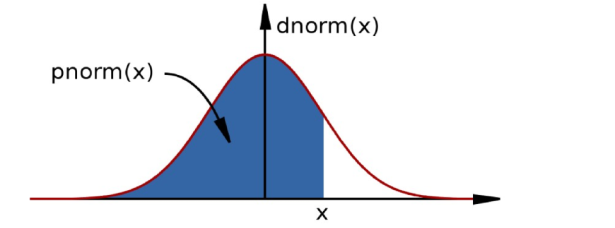

distributions

- Available for variety of distributions: `punif` (uniform), `pbinom` (binomial), `pnbinom` (negative binomial), `ppois` (poisson), `pgeom` (geometric), `phyper` (hyper-geometric), `pt` (T distribution), pf (F distribution)

## Distribution functions

- 10 random values from the Normal distribution with mean 10 and standard deviation 5:

```r
rnorm(10, mean=10, sd=5)
```

- The probability of drawing exactly 10 from this distribution:

```r
dnorm(10, mean=10, sd=5)
```

```
## [1] 0.07978846
```

```r
dnorm(100, mean=10, sd=5)
```

```
## [1] 3.517499e-72
```

## Distribution functions (continued)

- The probability of drawing a value smaller than 10:

```r
pnorm(10, mean=10, sd=5)
```

```
## [1] 0.5
```

- The inverse of `pnorm()`:

```r
qnorm(0.5, mean=10, sd=5)
```

```
## [1] 10
```

- How many standard deviations for statistical significance?

```r
qnorm(0.95, mean=0, sd=1)
```

```
## [1] 1.644854
```

## Example

Recall our histogram of Wind Speed from yesterday:

- The data look to be roughly normally-distributed
- An assumption we rely on for various statistical tests

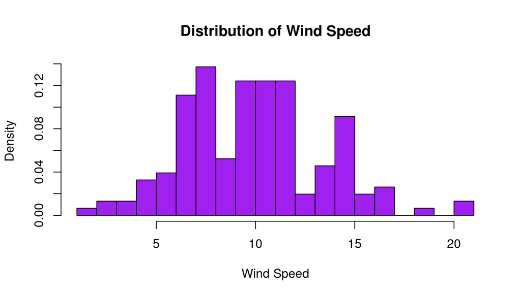

```r
weather <- read.csv("ozone.csv")
hist(weather$Wind, col="purple", xlab="Wind Speed",
     main="Distribution of Wind Speed",
     breaks = 20, freq=FALSE)
```

## Create a normal distribution curve

- If our data are normally-distributed, we can calculate the probability of drawing particular values.
  - e.g. a Wind Speed of 10

```r
tempMean <- mean(weather$Wind)
tempSD <- sd(weather$Wind)
dnorm(10, mean=tempMean, sd=tempSD)
```

- We can overlay this on the histogram using `points` as we just saw:

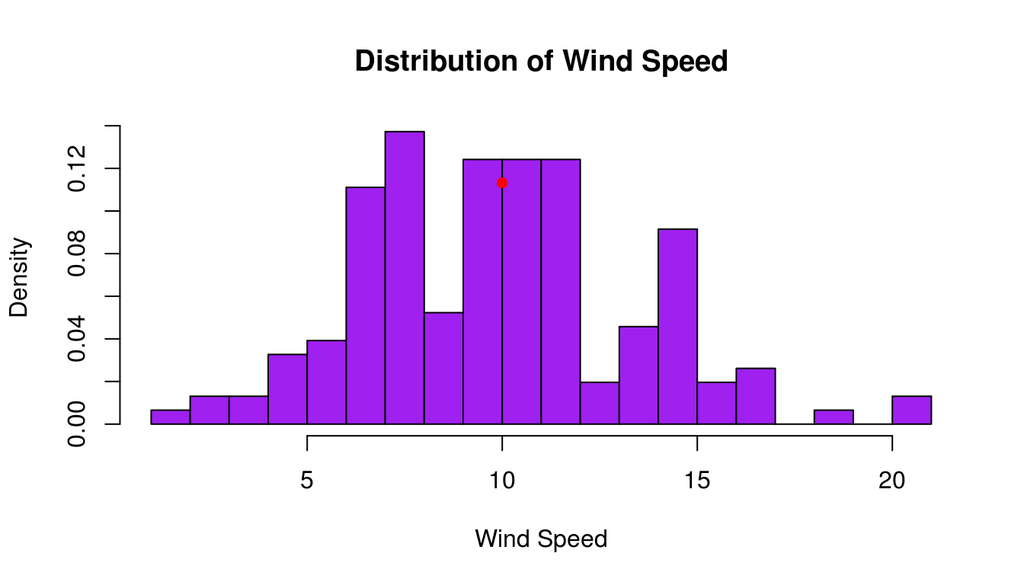

```r
hist(weather$Wind, col="purple", xlab="Wind Speed",
     main="Distribution of Wind Speed",
     breaks = 20, freq=FALSE)
points(10, dnorm(10, mean=tempMean, sd=tempSD),
       col="red", pch=16)
```

## Create a normal distribution curve

- We can repeat the calculation for a vector of values
  - remember that functions in R are often *vectorized*
  - use `lines` in this case rather than `points`

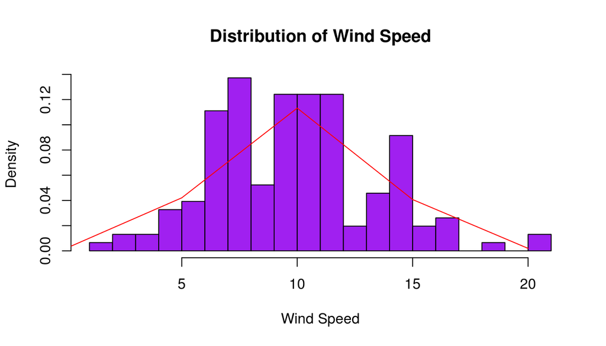

  ```r
  xs <- c(0,5,10,15,20)
  ys <- dnorm(xs, mean=tempMean, sd=tempSD)
  lines(xs, ys, col="red")
  ```

## Create a normal distribution curve

- For a smoother curve, use a longer vector:
  - we can generate x values using the `seq()` function
- Inspecting the data in this manner is usually acceptable to assess normality
  - the fit doesn’t have to be exact
  - the shapiro test is also available `?shapiro.test`

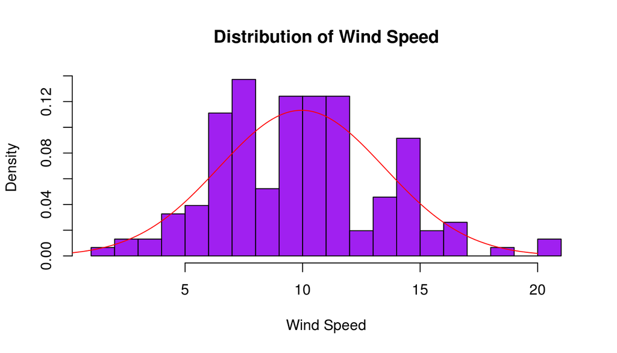

```r
xs <- seq(00,20, length.out = 10000)
ys <- dnorm(xs, mean=tempMean, sd=tempSD)
lines(xs, ys, col="red")
```

## Simple testing

- If we want to compute the probability of observing a particular Wind Speed, from the same distribution, we can use the standard formula to calculate a t statistic:

$$t = \frac{\bar{x} -\mu_0}{s / \sqrt(n)}$$

- Say a Wind Speed of 2; which from the histogram seems to be unlikely

```r
t <- (tempMean - 2) / (tempSD/sqrt(length(weather$Wind)))
t
```

```
## [1] 27.93897
```

## Simple testing

- …or use the **`t.test()`** function to compute the statistic and corresponding p-value

```r
t.test(weather$Wind, mu=2)
```

```
##
##  One Sample t-test
##
## data:  weather$Wind
## t = 27.939, df = 152, p-value < 2.2e-16
## alternative hypothesis: true mean is not equal to 2
## 95 percent confidence interval:
##   9.394804 10.520229
## sample estimates:
## mean of x
##  9.957516
```

## Two-sample tests: Basic data analysis

- Comparing 2 variances:
  - Fisher’s F test

```r
var.test()
```

- Comparing 2 sample means with normal errors:
  - Student’s t test

```r
t.test()
```

- Comparing 2 means with non-normal errors:
  - Wilcoxon’s rank test

```r
wilcox.test()
```

## Two-sample tests: Basic data analysis

- Comparing 2 proportions:
  - Binomial test
  - e.g. [here](http://www.r-tutor.com/elementary-statistics/inference-about-two-populations/comparison-two-population-proportions)

```r
prop.test()
```

- Correlating 2 variables:
  - Pearson’s / Spearman’s rank correlation

```r
cor.test()
```

- Testing for independence of 2 variables in a contingency table:
  - Chi-squared / Fisher’s exact test

```r
chisq.test(); fisher.test()
```

## Statistical tests in R

- Bottom-line: Pretty much any statistical test you care to name will probably be in R
  - This is not supposed to be a statistics course (sorry!)
  - None of them are particular harder than others to use
  - The difficulty is deciding which test to use:
    - whether the assumptions of the test are met, etc.
  - Consult your local statistician if not sure
  - An upcoming course that will help
    - [Introduction to Statistical Analysis](http://bioinformatics-core-shared-training.github.io/IntroductionToStats/)
  - Some good references:
    - [Statistical Analysis Using R (Course from the Babaraham Bioinformatics Core)](http://training.csx.cam.ac.uk/bioinformatics/event/1827771)
    - [Quick-R guide to stats](http://www.statmethods.net/stats/index.html)
    - [Simple R eBook](https://cran.r-project.org/doc/contrib/Verzani-SimpleR.pdf)
    - [R wiki](https://en.wikibooks.org/wiki/R_Programming/Descriptive_Statistics)
    - [R tutor](http://www.r-tutor.com/elementary-statistics)
    - [Statistical Cheatsheet](https://rawgit.com/bioinformatics-core-shared-training/intermediate-stats/master/cheatsheet.pdf)

## Example analysis

- We have already seen that men in our `patients` dataset tend to be heavier than women
- We can **test this formally** in R

```r
age    <- c(50, 21, 35, 45, 28, 31, 42, 33, 57, 62)
weight <- c(70.8, 67.9, 75.3, 61.9, 72.4, 69.9, 63.5,
            71.5, 73.2, 64.8)
firstName  <- c("Adam", "Eve", "John", "Mary", "Peter",
                "Paul", "Joanna", "Matthew", "David", "Sally")
secondName <- c("Jones", "Parker", "Evans", "Davis",
                "Baker","Daniels", "Edwards", "Smith",
                "Roberts", "Wilson")

consent <- c(TRUE, TRUE, FALSE, TRUE, FALSE, FALSE,
             FALSE, TRUE, FALSE, TRUE)

sex <- c("Male", "Female", "Male", "Female", "Male",
         "Male", "Female", "Male", "Male", "Female")

patients <- data.frame(First_Name = firstName,
                       Second_Name = secondName,
                       Full_Name = paste(firstName, secondName),
                       Sex = factor(sex),
                       Age = age,
                       Weight = weight,
                       Consent = consent,
                       stringsAsFactors = FALSE)
patients
```

```
##    First_Name Second_Name      Full_Name    Sex Age Weight Consent
## 1        Adam       Jones     Adam Jones   Male  50   70.8    TRUE
## 2         Eve      Parker     Eve Parker Female  21   67.9    TRUE
## 3        John       Evans     John Evans   Male  35   75.3   FALSE
## 4        Mary       Davis     Mary Davis Female  45   61.9    TRUE
## 5       Peter       Baker    Peter Baker   Male  28   72.4   FALSE
## 6        Paul     Daniels   Paul Daniels   Male  31   69.9   FALSE
## 7      Joanna     Edwards Joanna Edwards Female  42   63.5   FALSE
## 8     Matthew       Smith  Matthew Smith   Male  33   71.5    TRUE
## 9       David     Roberts  David Roberts   Male  57   73.2   FALSE
## 10      Sally      Wilson   Sally Wilson Female  62   64.8    TRUE
```

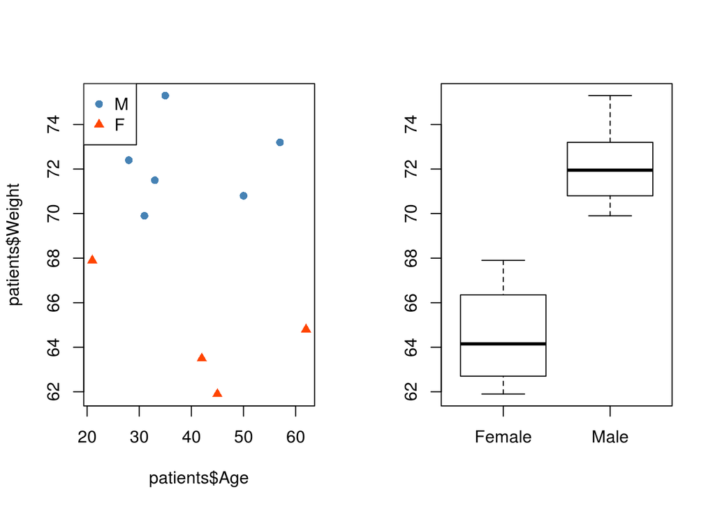

```r
males <- patients$Sex == "Male"
females <- patients$Sex == "Female"
par(mfrow=c(1,2))
plot(patients$Age, patients$Weight,pch=16,type="n")
points(patients$Age[males], patients$Weight[males],pch=16,col="steelblue")
points(patients$Age[females], patients$Weight[females],pch=17,col="orangered1")
legend("topleft", legend=c("M","F"),
       col=c("steelblue","orangered1"), pch=c(16,17))
boxplot(patients$Weight~patients$Sex)
```

## Test variance assumption

```r
var.test(patients$Weight~patients$Sex)
```

```
##
##  F test to compare two variances
##
## data:  patients$Weight by patients$Sex
## F = 1.759, num df = 3, denom df = 5, p-value = 0.5417
## alternative hypothesis: true ratio of variances is not equal to 1
## 95 percent confidence interval:
##   0.2265757 26.1830147
## sample estimates:
## ratio of variances
##           1.759041
```

## Perform the t-test

```r
t.test(patients$Weight~patients$Sex, var.equal=TRUE)
```

```
##
##  Two Sample t-test
##
## data:  patients$Weight by patients$Sex
## t = -5.4584, df = 8, p-value = 0.0006027
## alternative hypothesis: true difference in means is not equal to 0
## 95 percent confidence interval:
##  -10.893759  -4.422908
## sample estimates:
## mean in group Female   mean in group Male
##             64.52500             72.18333
```

- This function can be tuned in various ways (`?t.test`):
  - Assumed equal variances, or not (and use Welch’s correction)
  - Deal with paired samples
  - Two-sided, or one-sided p-value

## Linear regression: Basic data analysis

- Linear modeling is supported by the function **`lm()`**:
  - `example(lm)`
  - The output assumes you know a fair bit about the subject
- `lm` is really useful for plotting lines of best fit to XY data, in order to determine intercept, gradient and Pearson’s correlation coefficient
  - This is very easy in R
- Three steps to plotting with a best fit line:
  1. Plot XY scatter-plot data
  2. Fit a linear model
  3. Add bestfit line data to plot with `abline()` function

## Typical linear regression analysis: Basic data analysis

- The ~ (*tilde*) is used to define a *formula*; i.e. “y is given by x”

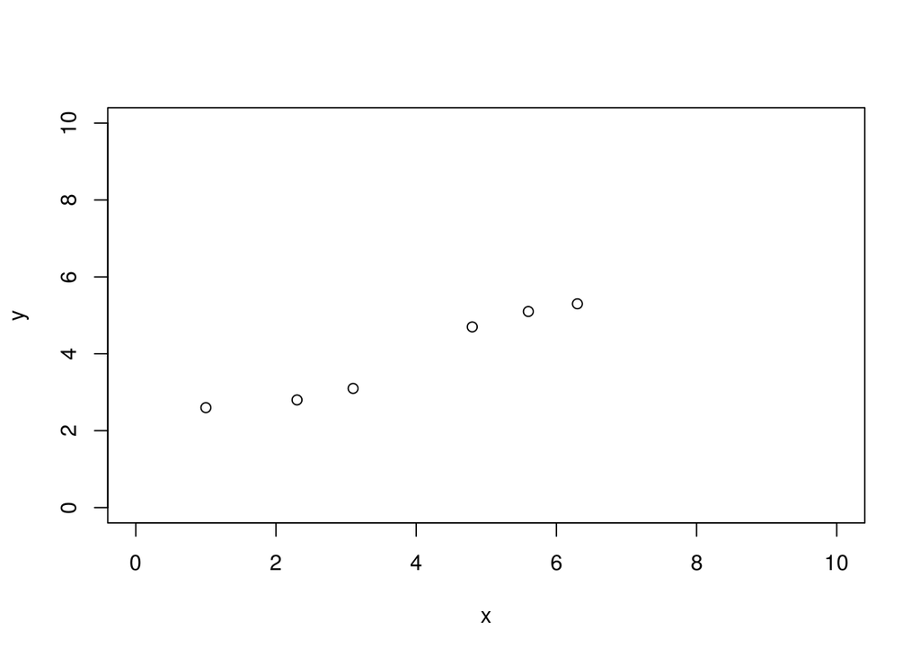

```r
x <- c(1, 2.3, 3.1, 4.8, 5.6, 6.3)
y <- c(2.6, 2.8, 3.1, 4.7, 5.1, 5.3)
plot(x,y, xlim=c(0,10), ylim=c(0,10))
```

## Typical linear regression analysis: Basic data analysis

The ~ is used to define a formula; i.e. “y is given by x” - Take care about the order of x and y in the plot and lm expressions

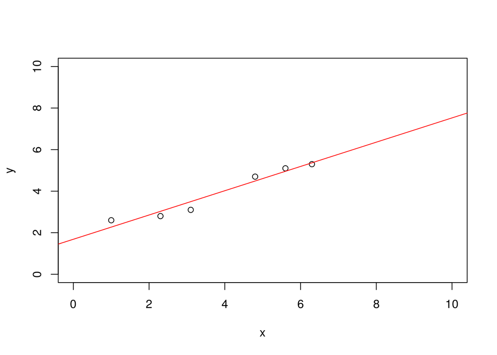

```r
plot(x,y, xlim=c(0,10), ylim=c(0,10))
myModel <- lm(y~x)
abline(myModel, col="red")
```

## In-depth summary

```r
summary(myModel)
```

```
##
## Call:
## lm(formula = y ~ x)
##
## Residuals:
##        1        2        3        4        5        6
##  0.33159 -0.22785 -0.39520  0.21169  0.14434 -0.06458
##
## Coefficients:
##             Estimate Std. Error t value Pr(>|t|)
## (Intercept)  1.68422    0.29056   5.796   0.0044 **
## x            0.58418    0.06786   8.608   0.0010 **
## ---
## Signif. codes:  0 '***' 0.001 '**' 0.01 '*' 0.05 '.' 0.1 ' ' 1
##
## Residual standard error: 0.3114 on 4 degrees of freedom
## Multiple R-squared:  0.9488, Adjusted R-squared:  0.936
## F-statistic:  74.1 on 1 and 4 DF,  p-value: 0.001001
```

## Typical linear regression analysis: Basic data analysis

- Get the coefficients of the fit from:

```r
coef(myModel)   # Coefficients
resid(myModel)  # Residuals
fitted(myModel) # Fitted values
names(myModel)  # Names of the objects within myModel
residuals(myModel) + fitted(myModel) # what values does this give?
```

## Diagnostic plots of the fit

- Get QC of fit from:
  - Some explanation is given [here](http://data.library.virginia.edu/diagnostic-plots/) and [here](http://strata.uga.edu/6370/rtips/regressionPlots.html)

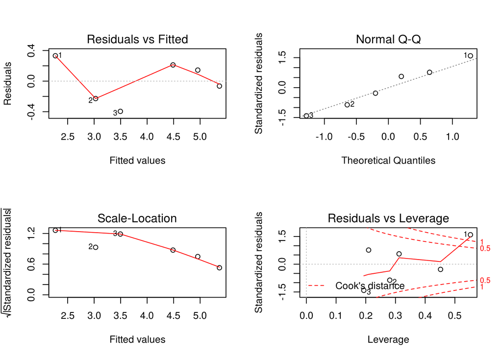

```r
par(mfrow=c(2,2))
plot(myModel)
```

## Modelling formulae

- R has a very powerful formula syntax for describing statistical models
- Suppose we had two explanatory variables `x` and `z`, and one response variable `y`
- We can describe a relationship between, say, `y` and `x` using a tilde `~`, placing the response variable on the left of the tilde and the explanatory variables on the right:
  - `y~x`
- It is very easy to extend this syntax to do multiple regressions, ANOVAs, to include interactions, and to do many other common modelling tasks. For example

```r
y~x       #If x is continuous, this is linear regression
y~x       #If x is categorical, ANOVA
y~x+z     #If x and z are continuous, multiple regression
y~x+z     #If x and z are categorical, two-way ANOVA
y~x+z+x:z # : is the symbol for the interaction term
y~x*z     # * is a shorthand for x+z+x:z
```

## Exercise: Exercise 6

- There are suggestions that Ozone level could be influenced by Temperature:

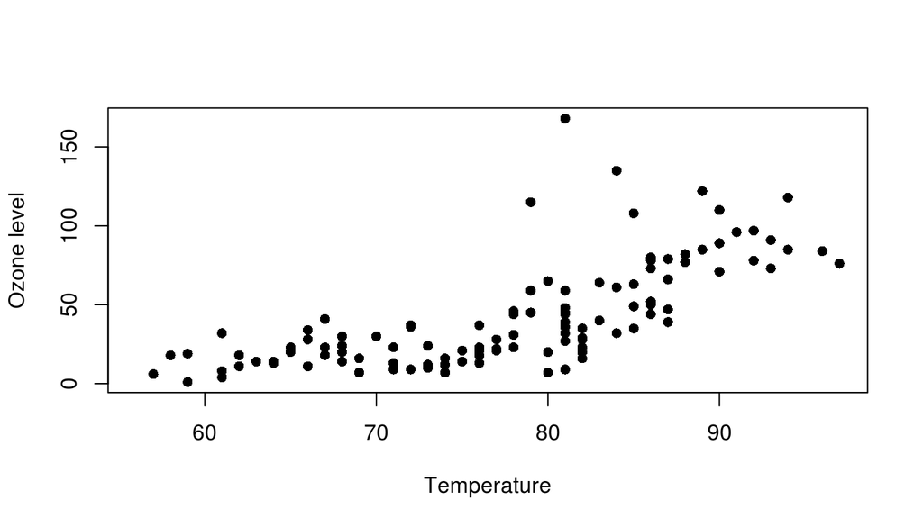

- Perform a linear regression analysis to assess this:
  - Fit the linear model and print a summary of the output
  - Plot the two variables and overlay a best-fit line
  - What is the equation of the best-fit line in the form
    - $$y = mx + c$$
  - Calculate the correlation between the two variables using the function `cor` (`?cor`)
    - can you annotate the plot with the correlation coefficient?

## Word of caution

*Correlation != Causation*

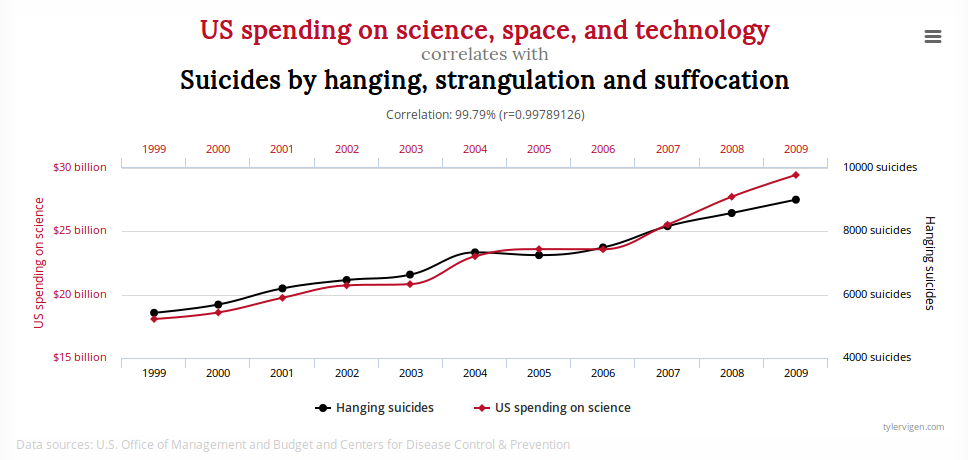

http://tylervigen.com/spurious-correlations

## Word of caution

[figure not shown]

[So if I want to win a nobel prize, I should eat even more chocolate?!?!?](http://www.businessinsider.com/chocolate-consumption-vs-nobel-prizes-2014-4?IR=T)

But no-one would ever take such trends seriously….would they?

## Wrong!

[figure not shown]

Cutting-down on Ice Cream was recommended as a safeguard against polio!